**Faire une copie du Notebook pour qu'il soit identifié comme le vôtre:** `Make a copy` (`Faire une copie`) dans le menu déroulant `File`(`Fichier`) .  
**Renommer la copie TPx_yyy_nom1_nom2.ipynb ( où x=1 ou 2 ou 3 ou 4 numéro du TP et yyy:OPS -> Notebook d'analyse, yyy-> Camera_Image):** `Rename` (`Renommer`) dans le menu déroulant `File`(`Fichier`).

[figure not shown]

# Licence Physique, Université Lyon 1

# U.E. PHY2005L : "Optique physique et spectroscopie "

## Consignes pour les étudiants

- **Exécution**

**Exécuter toujours le notebook depuis le début** (en appuyant sur le bouton **`Exécuter`** ou **`Run`**) cellule après cellule. En effet un notebook est un programme et pas une simple page HTML qui doit s'exécuter dans l'ordre du début à la fin.

**Suivre les instructions pour remplir les cellules** de `code` (calcul python) avec vos données expérimentales ou de texte `markdown` puis `Exécuter` la cellule.

- **En cas de problème**

Tout d'abord, `redémarrer le noyau` (dans la barre de menus, sélectionnez **`Noyau -> Redémarrer`** ou **`Kernel -> Restart`**), puis exécuter toutes les cellules (dans la barre de menus, sélectionnez **`Cellule -> Executer tout`** ou **`Cell -> Run All`**).

-**`Exécuter`** la cellule suivante:

```python
from IPython.display import Markdown,display
```

- **Dans la cellule suivante :**  
  $\rightarrow$ *Remplacer* *par vos noms, prénoms et numéros d'étudiant du binôme les données renseignées dans la cellule suivante:*  
  puis **`Exécuter`** les 2 cellules suivantes.

```python
NOM1    = "TARAS"
PRENOM1 = "DIMITRI"
NUMERO_ETUDIANT1 = 12107771
NOM2    = "SCHIFANO"
PRENOM2 = "ALEXANDRE"
NUMERO_ETUDIANT2 = 12103429
```

```python
if type(NUMERO_ETUDIANT1) is not int:
    print("ERREUR: numéro d'étudiant non spécifié!!!")
else:
    display(Markdown("**Etudiant:** {} {}  **ID:** {}"
                     .format(NOM1,PRENOM1,NUMERO_ETUDIANT1)))

if type(NUMERO_ETUDIANT2) is not int:
    print("ERREUR: numéro d'étudiant non spécifié!!!")
else:
    display(Markdown("**Etudiant:** {} {}  **ID:** {}"
                     .format(NOM2,PRENOM2,NUMERO_ETUDIANT2)))
```

**Etudiant:** TARAS DIMITRI **ID:** 12107771

**Etudiant:** SCHIFANO ALEXANDRE **ID:** 12103429

La cellule ci-dessous contient l'ensemble du code python qui permet d'importer les bibliothèques ou modules nécessaires à l'éxécution de ce Notebook-Jupyter → Cliquer sur la cellule et `Executer`

```python
import numpy as np
import scipy as sc
from scipy.optimize import curve_fit
import pandas as pd
import matplotlib.pyplot as plt
from sklearn.metrics import r2_score
%matplotlib inline
```

```python
#NOM1="NOM1";NOM2="NOM2";
#NOM3="NOM_etudiant3";noms=NOM1+'-'+NOM2+'-'+NOM3; # à utiliser pour un trinôme
noms=NOM1+'-'+NOM2
noms
```

```
'TARAS-SCHIFANO'
```

# manipulation 4 : Spectre visible de l'atome d' hydrogène

## objectif

Il s'agit de réaliser la spectroscopie des raies d'émission de l'hydrogène atomique dans le domaine visible, c'est-à-dire de mesurer les longueurs d'onde du rayonnement émis par l'atome d'hydrogène. (voir le préambule du TP2 pour une définition de la "spectroscopie".)

Le montage expérimental est composé de trois éléments :

- une lampe spectrale générant le rayonnement électromagnétique à étudier ;
- un monochromateur permettant de disperser le rayonnement en fonction de la longueur d'onde suivant la relation de diffraction par un réseau :  
  $\sin(\theta_p)-\sin(\theta_0)= n p \lambda $ où $n$ est le nombre de traits par unité de longueur du réseau, $p$ l'ordre d'observation et $\lambda$ la longueur d'onde du rayonnement diffracté.  
  Le monochromateur est construit pour que mécaniquement la position angulaire différentielle $d$ (qui dépend des angles) donne la relation affine $\lambda=a*d$. La position angulaire est directement enregistrée par le logiciel Capstone .
- une photodiode qui convertit les photons en signal électrique directement exploitable par le logiciel Capstone .

Pour obtenir le spectre de l'hydrogène, il faut **étalonner le monochromateur à l'aide d'un spectre connu, ici le spectre du mercure (Hg)**.

Les spectres observés (de H et de Hg) sont des spectres de raies d'émission, c'est-à-dire qu'ils sont formés d'une suite discrète de longueurs d'onde. Ceci est une conséquence directe de la quantification de l'énergie d'un atome, c'est-à-dire que celle-ci ne peut prendre que certaines valeurs particulières. L'atome d'hydrogène ne comportant qu'un électron, la description théorique en est simple et est présentée dans la suite. On analysera les mesures dans le cadre de ce modèle.

## 1. Dispositif expérimental et étalonnage.

Installer la lampe à mercure dans le montage expérimental, à l'aide du logiciel Capstone vérifier que la lumière éclaire correctement le réseau.

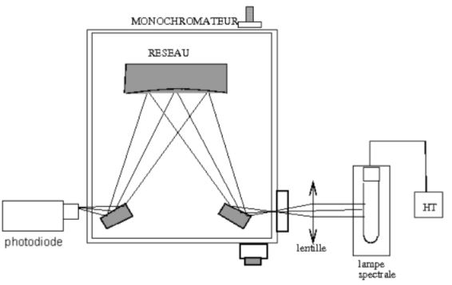

- **ATTENTION : positionner la molette, qui oriente le réseau, en butée avant chaque enregistrement du spectre d'une lampe.**
- **Faire valider votre montage par l'encadrant de TP**

**Réglages** --> "cahier de manip": :

- comment positionner la lentille :

### 1. a) étalonnage du monochromateur

Le but est de vérifier que le monochromateur obéit à une relation $\lambda=a*d_{raie}$ où $d_{raie}$ est la distance entre un pic correspondant à l'émission d'une raie et l'ordre zéro du monochromateur $d_{raie}=d_{pic}-d_0$ où $d_{pic}$ est la position d'un pic sur le spectre et $d_0$ la position de l'ordre zéro. En effet l'ordre zéro $p=0$ dépend seulement du réseau il correspond à $\sin(\theta_{p=0})-\sin(\theta_0)= n\times 0 \times\lambda $, c'est un paramètre expérimental.

- Il faut donc faire une mesure différentielle de la position angulaire des raies d'émission du mercure $d_{raie}$ par rapport au pic d'ordre zéro.
- Au pic d'ordre zéro on attribuera la valeur $p*\lambda=0$.

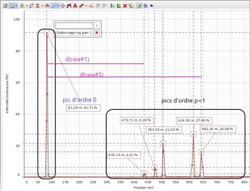

```python
#données pour le mercure (Hg) dans des tableaux np.array([])
lambdaHg=np.array([365.2,404.83,435.83,546.07,576.96,579.07])
couleurHg=np.array(['U.V','violet','indigo','vert','jaune1','jaune2'])

#résumé des valeurs connues sur le Hg: (permet de comprendre l'écriture dans un tableau de données)
print("Voici les données connues sur le spectre de raies d'émission du mercure")
Hg={'$λ_{Hg}$ (nm)':lambdaHg}
Hg_data=pd.DataFrame(index=couleurHg,data=Hg)
Hg_data
```

```
Voici les données connues sur le spectre de raies d'émission du mercure
```

|  | $λ_{Hg}$ (nm) |
| --- | --- |
| U.V | 365.20 |
| violet | 404.83 |
| indigo | 435.83 |
| vert | 546.07 |
| jaune1 | 576.96 |
| jaune2 | 579.07 |

**Protocole**

- Faire une acquisition du spectre de la lampe Hg sans aucun filtre avec le logiciel Capstone .
- Pointer les raies observées (trouver la valeur $d_{raie}$ de la raie d'émission et son incertitude $\Delta d$).
- Insérer l'un des filtres spectraux (bleu, vert et jaune) et refaire une acquisition.
- Répéter l'opération avec chacun des filtres.
- Ne pas oublier de faire une copie d'écran des spectres enregistrés pour votre compte-rendu (par exemple)

$\rightarrow$ **Faire valider vos mesures par l'encadrant de TP**.

**Questions:**

1. Combien de pics sont enregistrées sur votre graphe en l'absence de filtre?
2. Combien de raies d'émission du Hg sont enregistrées sur votre spectre en l'absence de filtre?
3. Combien de raies sont enregistrées en présence d'un filtre?
4. l'ordre d'observation $p$ du réseau pour ces raies $p=?$
5. Le doublet jaune est-il observé? est-il scindé en 2 raies sur vos spectres?  
   $\rightarrow$ conclure à partir de ces observations sur la détermination de la longeur d'onde des raies expérimentalement observées.
- Insérer ici la copie d'écran des spectres obtenus avec </font> Capstone sur un seul graphe.

(Pour insérer une figure au format image il suffit d'utiliser le menu du Notebook : `Edit` puis `Insert Image`)

- Réponses :  
sans bleu jaune vert

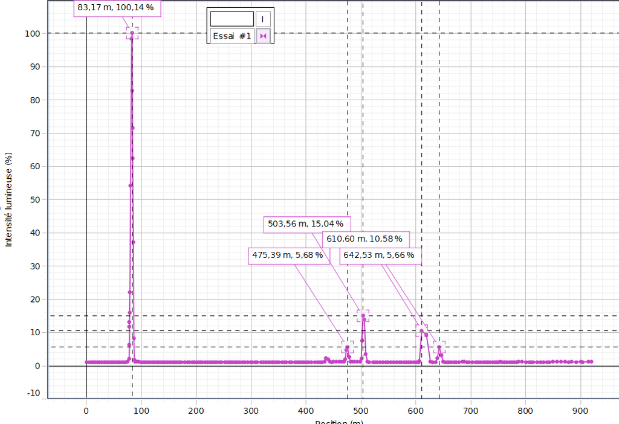

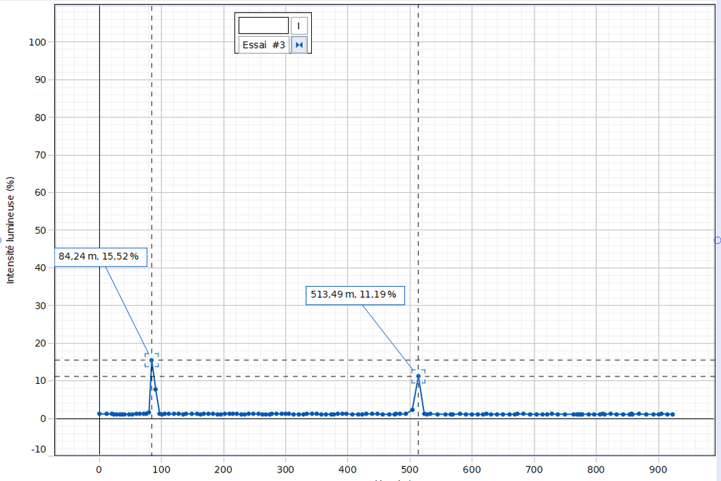

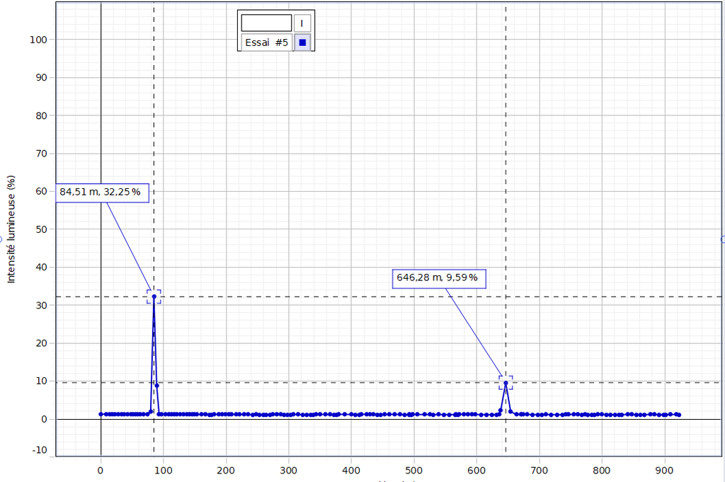

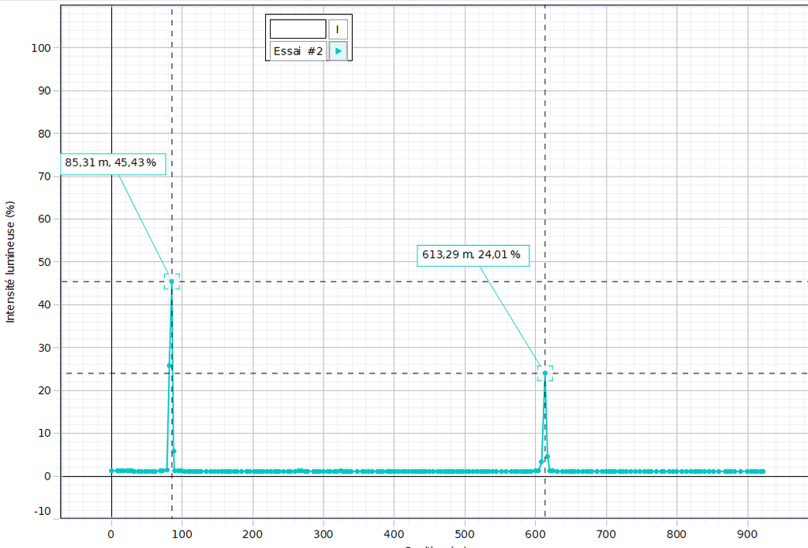

**Mesures :**  
$\rightarrow$ *Remplacer* *par vos mesures les données renseignées dans la cellule suivante:*  
**(suivre les instructions indiquées en vert et précédées d'un #.)**

```python
#données expérimentales:

# nommer les raies observées sur le spectre enregistré:
numero_raie=np.array(["ordre0","raie #1","raie #2","raie #3","raie #4","raie #5",])

# position "d"  des raies sur le spectre--> remplacer les valeurs de la liste ci-dessous avec vos pointers.
dp0=83.17 # position de l'odre zéro sur le graphe
dpic=np.array([83.17,435,475.39,503.56,610.60,642.53]) #position de tous les pics observés sur le graphe
delta_d=np.array([3,3,3,3,3,3])
d=dpic-dp0 # position différentielle des raies du mercure
incertitude_mesure_d=7

#indiquer le filtre qui laisse passer le pic observé sur le graphe
filtre=np.array(['BVJ','--','--','Bleu','Vert','Jaune'])

#-->faire  une attribution (d->LongOnde) dans la liste ci-dessous.
#indiquer les valeurs en nm des pics ou raies, observées dans le spectre, par orde de λ croissant
longOnde=np.array([0,365.2,404.83,435.83,546.07,578])
```

```python
tableau=np.ones(len(d))

print("Position odre 0 dp0=",dp0,"Tableau résumé des données spectrales de Hg obtenues avec le monochromateur")
#Mise en forme d'un tableau des données:
calibration={noms+' d$_{raie}$ (u.a)':d,'incertitude Δd (u.a.)':delta_d,
             'Filtre':filtre,' p*$\lambda_{Hg}$ (nm)':longOnde}
calibration_data=pd.DataFrame(index=numero_raie,data=calibration)
calibration_data
```

```
Position odre 0 dp0= 83.17 Tableau résumé des données spectrales de Hg obtenues avec le monochromateur
```

|  | TARAS-SCHIFANO d$_{raie}$ (u.a) | incertitude Δd (u.a.) | Filtre | p*$\lambda_{Hg}$ (nm) |
| --- | --- | --- | --- | --- |
| ordre0 | 0.00 | 3 | BVJ | 0.00 |
| raie #1 | 351.83 | 3 | -- | 365.20 |
| raie #2 | 392.22 | 3 | -- | 404.83 |
| raie #3 | 420.39 | 3 | Bleu | 435.83 |
| raie #4 | 527.43 | 3 | Vert | 546.07 |
| raie #5 | 559.36 | 3 | Jaune | 578.00 |

#### Analyse des données : méthode

$\rightarrow$ Vérifier la relation $\lambda=a*d $ entre les valeurs $d$ des raies pointées et les longueurs d'onde $\lambda_{Hg}$ des raies observées, à partir des éléments suivants :

- Vérifier la concordance des valeurs dans le tableau pour obtenir une relation linéaire entre $d$ et $\lambda$
- Réaliser une régression linéaire de la longueur d'onde en fonction la position angulaire du réseau $\lambda =a *d$:

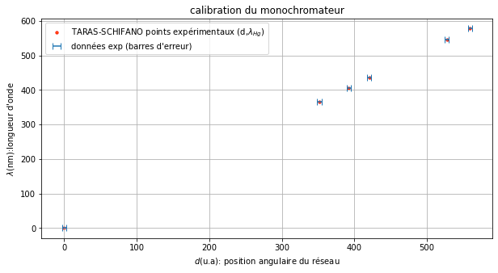

```python
# représentation graphique des points de calibration : est ce une droite ?

fig, ax = plt.subplots(figsize=(10, 5))
ax.scatter(d,longOnde,s=10,facecolor='C1', edgecolor='r',label=noms+" points expérimentaux (d,$\lambda_{Hg}$)")
#ax.plot(d,longOnde,color='green',label=noms+"  segments de droite reliant les points expérimentaux (d,$\lambda_{Hg}$)")
ax.errorbar(d,longOnde,xerr=delta_d, marker='',capsize=4,linestyle='',label="données exp (barres d'erreur)")
ax.set_title("calibration du monochromateur")
ax.set_ylabel("$\lambda$(nm):longueur d'onde ")
ax.set_xlabel("$d$(u.a): position angulaire du réseau")
ax.legend()
ax.grid()
plt.show()
```

**Représentation graphique des points de calibration** :  
Les points expérimentaux sont-ils alignés? Commentez les valeurs avec les barres d'erreur.

→ Vérifier les valeurs de votre tableau pour obtenir une relation linéaire entre $d$ (u.a.) et $\lambda$ (nm).  
→ On réalise alors une régression linéaire de la longueur d'onde en fonction la position angulaire du réseau :  
$\lambda=a\times d_{raie}$.

Réponses :

**Régression linéaire** : Lorsque des points expérimentaux s'alignent on utilise un ajustement linéaire pour déterminer le paramètre de la droite $y=ax$ où $a$ est la pente. Ce paramètre, déterminé par la fonction `sc.optimize.curve_fit( λ_fit, x, y, sigma = Δx )` où `λ_fit(x,a_fit)`est une fonction linéaire, doit pouvoir être interprété physiquement.

Ici il s'agit d'une relation d'étalonnage $y\rightarrow \lambda$ et $x\rightarrow d$ reliées par $\lambda = a *d$ où $d$ est la position différentielle du pic de la raie d'émission.

```
paramètres : a= 1.0348 Δa= 0.0008
```

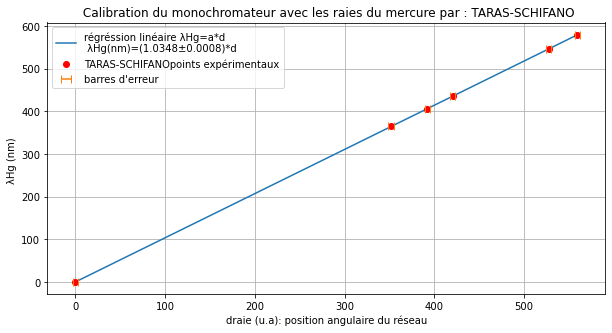

```python
# régression linéaire de λ= a*d=f(d)  et d=b*λ est une droite passant par l'origine avec b=1/a
#  l'abscisse est x=λ, l'ordonnée est y=d, elles sont reliées par la relation y=b_fit*x dans la fonction λ_fit(x,b_fit)
x = d # en u.a.
Δx = delta_d
y = longOnde #en nm

def λ_fit(x,a_fit):return a_fit*x
p2opt, p2cov = sc.optimize.curve_fit( λ_fit, x, y, sigma = Δx ) #permet de faire un ajustement linéaire
a=p2opt[0]; # valeur du paramètre  ajusté   a_fit
Δa=p2cov[0,0]**0.5; # valeur de l'incertitude du paramètre ajusté Δa_fit
print('paramètres : a=',np.round(a,4),'Δa=',np.round(Δa,4))

#figure
%matplotlib inline
fig, ax = plt.subplots(figsize=(10, 5))
ax.set_title(" Calibration du monochromateur avec les raies du mercure par : "+noms)
ax.set_xlabel("draie (u.a): position angulaire du réseau")
ax.set_ylabel("λHg (nm) ")
ax.plot(x, (λ_fit(x, *p2opt)), label=f"régréssion linéaire λHg=a*d \n λHg(nm)=({a:.4f}\u00B1{Δa:.4f})*d ")
ax.plot(x,y, 'ro',label=noms+"points expérimentaux")
ax.errorbar(d,longOnde,xerr=delta_d, marker='',capsize=4,linestyle='',label="barres d'erreur")
ax.legend()
ax.grid()
plt.show()
```

Commenter le résultat : La relation entre la longueur d'onde du mercure avec la position angulaire du réseau est affine (droite passant par l'origine).

**Faire valider votre étalonnage par l'encadrant de TP.**

A partir de maintenant les longueurs d'onde d'un spectre sont déterminées par leur position $d_{raie}=d_{pic}-d_0$.

- $\lambda (nm)=(a\pm\Delta a)\times d_{raie}$
- Montrer ( par différenciation de la fonction $\lambda=a\times d$) que $\Delta \lambda (nm)=a \Delta d+d\Delta a$

( vous pouvez soit utiliser latex pour écrire les équations soit scanner votre feuille manuscrite et insérer une figure à partir de `insérer une image` du menu déroulant de `Edition`)

Démonstration: plus tard

```python
# fonctions de détermination d'une longueur d'onde λ à partir de la position d.
def calibration(d): return a*d
def Δcalibration(d,Δd):return a*Δd+d*Δa
```

### 1. b) Résolution du monochromateur : 8 nm/mm

**La résolution des monochromateurs en salle de TP est de 8 nm/mm**. Elle dépend des largeurs des fentes d'entrée et de sortie de l'appareil. Avec les fentes de $0.5$ mm, le monochromateur sépare au mieux deux raies distantes de $4$ nm, il ne peut donc pas résoudre le doublet jaune du Hg constitué par les raies $\lambda_1=576.96$nm et $\lambda_2=579.07$nm.

- Expliquer l'allure observée pour le pic #5 :
- La résolution de l'appareil influence-t-elle l'incertitude de mesure des pics pointés $\Delta d$?

Réponses :

En insérant les fente de 0.1 mm, sa résolution est de 0.8 nm. Il est donc possible d'observer les deux raies du doublet jaune de Hg.

- Remplacer les fentes de 0.1 mm sur l'appareil et faire un enregistrement du spectre.
- Faire un zoom sur le pic du doublet jaune et une copie d'écran.
- Le doublet est-il séparé ?
- **faire valider votre graphe par l'encadrant de TP**

Commenter le spectre de Hg obtenu avec les système de fentes de 0.1mm:

- insérer le graphe du zoom du pic#5
- commentaires:

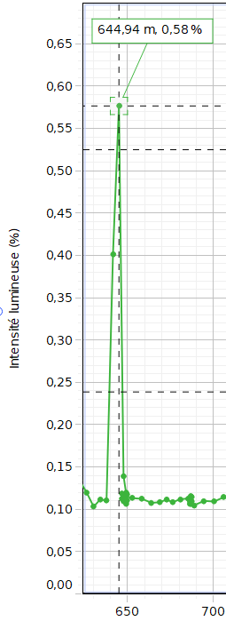

### Remettre les fentes d'entrée et de sortie de 0.5mm pour lesquelles la relation de calibration a été déterminée.

## 2. Série de Balmer de l'hydrogène → détermination expérimentale de la constante de Rydberg

## Mesures:

- Remplacer la lampe à mercure (l'éteindre) par la lampe à hydrogène,
- Faire un enregistrement du spectre (au moins 3 raies sont observées) avec le logiciel Capstone en ayant pris soin de positionner la molette en butée.
- **Faire valider votre graphe par l'encadrant de TP** puis faire une copie d'écran du spectre pour votre compte-rendu.
- Pointer les raies et remplacer les valeurs dans le tableau dH ci-dessous,

Insérer le graphe obtenu pour la lampe à hydrogène et le commenter :

(Pour insérer une figure au format image il suffit d'utiliser le menu du Notebook : `Edit` puis `Insert Image`)

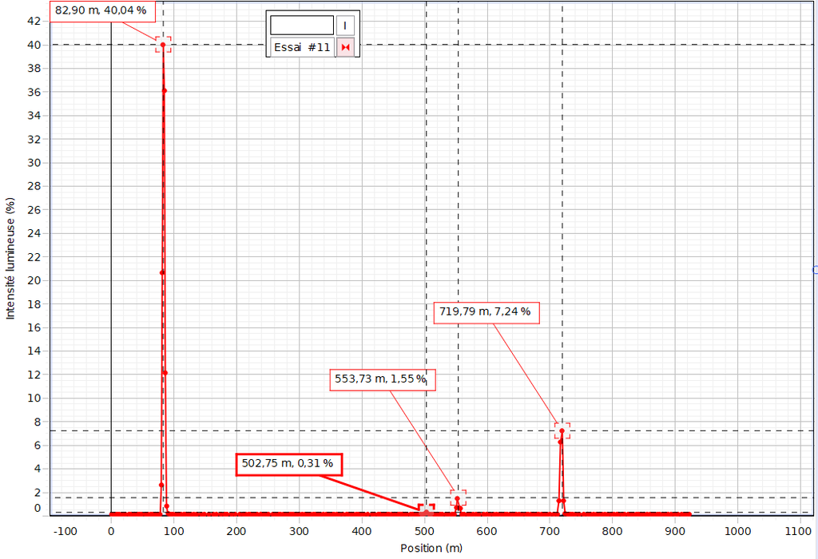

$\rightarrow$ *Remplacer* *par vos mesures les données renseignées dans la cellule suivante:*  
**(suivre les instructions indiquées en vert et précédées d'un #.)**

```python
#mesures des raies de l'hydrogène à partir du spectre enregistré:

#ATTENTION-> ordre des raies en énergie de photon croissante c'est à dire en λ(H) ou d(H) décroissante.
raieH=np.array(['raie #1','raie #2','raie #3'])

#position des pics du spectre de l'hydrogène (λ(H) décroissante).
#-> remplacer les valeurs d des pointers de raies de la liste ci-dessous par vos mesures
#(min 3 raies Max 4 raies, dans l'odre de d décroissant)
dH0=82.90 # possition de l'ordre d'observation 0 sur le spectre
dH=np.array([719.79,553.73,502.75]) #position des pics sur le spectre
dH=dH-dH0
incertitude_mesure_dH=7
```

```python
tableauH=np.ones(len(raieH))
delta_dH=incertitude_mesure_dH*tableauH

#attribution des λ grâce à la fonction de calibration obtenue avec la lampe Hg (longOndeH=a*dH+b)
longOndeH=calibration(dH)
ΔλH=Δcalibration(dH,delta_dH)

print("Position ordre 0 dH0=",dH0," tableau des données expérimentales collectées pour la lampe à hydrogène :")
#tableau des données:
Hydrogène={noms+' position d$_{raieH}$ (u.a)':dH,
           'Δd$_H$ (u.a)':delta_dH,
           'λ$_H$(nm)':np.round(longOndeH,1),
           'Δλ$_H $(nm)':np.round(ΔλH,1)
          }
Hydrogène_data=pd.DataFrame(index=raieH,data=Hydrogène)
Hydrogène_data
```

```
Position ordre 0 dH0= 82.9  tableau des données expérimentales collectées pour la lampe à hydrogène :
```

|  | TARAS-SCHIFANO position d$_{raieH}$ (u.a) | Δd$_H$ (u.a) | λ$_H$(nm) | Δλ$_H $(nm) |
| --- | --- | --- | --- | --- |
| raie #1 | 636.89 | 7.0 | 659.1 | 7.8 |
| raie #2 | 470.83 | 7.0 | 487.2 | 7.6 |
| raie #3 | 419.85 | 7.0 | 434.5 | 7.6 |

## Interprétation : à partir du diagramme des transitions de l'hydrogène

##### a) Détermination des longueurs et nombres d'onde théoriques :

- Soit l'énergie quantifiée des niveaux de H : $E_n(eV)=\frac{-13.6}{n^2} $.
- La variation d'énergie dans l'atome H lors de la désexcitation radiative de la série de Balmer est : $\Delta E_{H}=E_{final}-E_{initial}=E_2-E_n$.
- L'émission du photon correspondant est caractérisée par $\Delta E_{photon}=-\Delta E_{H}=E_n-E_2=\frac{h c}{\lambda_{n\rightarrow2}}=h c \sigma_{n\rightarrow2}$ où le nombre d'onde $\sigma_{n\rightarrow2}$ est défini par :$\sigma_{n\rightarrow2}(cm^{-1})=\frac{1}{\lambda_{n\rightarrow2}(cm)}$

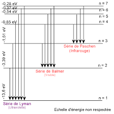

- Montrer que $\lambda_{n\rightarrow2}=\frac{h c}{E_n-E_2}$

Démonstration :

Remarques :

$\rightarrow$ *Remplacer* *par vos mesures les données renseignées dans la cellule suivante:*  
**(suivre les instructions indiquées en vert et précédées d'un #.)**

```python
# indiquer quels sont les n des états excités impliqués dans les désexcitations radiatives observées vers le niveau n=2
n=np.array([3,4,5])
```

```python
#Série de Balmer : calcul théorique des longueurs d'onde et nombres d'onde depuis les états excités n=3,4,5,6...

#constantes
h=6.62607004e-34
c=3e8
e=1.6e-19

#énergie du photon émis en eV
E_n2=-13.6/(n**2)+13.6/4

# longueur d'onde en nm il faut convertir l'énergie en Joule (*e) et passer en nm
#rmq :(*1O^9--> 1e9 dans la plupart des langages informatiques)
longOndeTheo=1e9*h*c/(e*E_n2) #exprimée en nm

#sigma en cm-1, à partir de longueur d'onde en cm
sigmatheo=1/(longOndeTheo*1e-7) #exprimée en cm-1

print(" résumé des valeurs théoriques de la série de Balmer:")
#tableau résumé :
NRJ={'état excité n':n,'$E_{photon}^{n -> 2}$(eV)':E_n2,'$\lambda_{théorique}^{n -> 2}$(nm)':longOndeTheo,
     '$\sigma_{théorique}^{n -> 2}$ (cm$^{-1}$)':sigmatheo}
NRJ_data=pd.DataFrame(index=raieH,data=NRJ)
NRJ_data
```

```
 résumé des valeurs théoriques de la série de Balmer:
```

|  | état excité n | $E_{photon}^{n -> 2}$(eV) | $\lambda_{théorique}^{n -> 2}$(nm) | $\sigma_{théorique}^{n -> 2}$ (cm$^{-1}$) |
| --- | --- | --- | --- | --- |
| raie #1 | 3 | 1.888889 | 657.734894 | 15203.69... |
| raie #2 | 4 | 2.550000 | 487.211032 | 20524.98... |
| raie #3 | 5 | 2.856000 | 435.009850 | 22987.98... |

##### b) Attribution des transitions observées dans le spectre

On montrera que $\frac{\Delta \lambda}{\lambda}=\frac{\Delta \sigma}{\sigma}$ par différenciation de $\Delta E_{photon}=\frac{h c}{\lambda_{n\rightarrow2}}=h c \sigma_{n\rightarrow2}$

Démonstration : plus atrd

Remarques :

```python
#données  expérimentales: calcul du nombre d'onde σH et de ΔσH:
sigmaH=1e7/longOndeH #en cm^-1
ΔσH=sigmaH*ΔλH/longOndeH #en cm^-1

print("Tableau résumé des valeurs théoriques et expérimentales:")

#tableau résumé des valeurs expérimentales et théoriques:
NRJtout={'n:état excité':n,'λthéo(nm)':np.round(longOndeTheo,1),
         'λexp(nm)':np.round(longOndeH,1),'Δλexp(nm)':np.round(ΔλH,1),
         'σthéo(cm $^{-1}$)': np.round(1e7/longOndeTheo,0),
         'σexp(cm$^{-1}$)':np.round(sigmaH,0),
         'Δσ(cm$^{-1}$)':np.round(ΔσH,0),
         '${\Delta\sigma}/{\sigma}$' :ΔσH/sigmaH
        }
NRJtout_data=pd.DataFrame(index=raieH,data=NRJtout)
NRJtout_data
```

```
Tableau résumé des valeurs théoriques et expérimentales:
```

|  | n:état excité | λthéo(nm) | λexp(nm) | Δλexp(nm) | σthéo(cm $^{-1}$) | σexp(cm$^{-1}$) | Δσ(cm$^{-1}$) | ${\Delta\sigma}/{\sigma}$ |
| --- | --- | --- | --- | --- | --- | --- | --- | --- |
| raie #1 | 3 | 657.7 | 659.1 | 7.8 | 15204.0 | 15173.0 | 179.0 | 0.011811 |
| raie #2 | 4 | 487.2 | 487.2 | 7.6 | 20525.0 | 20524.0 | 322.0 | 0.015688 |
| raie #3 | 5 | 435.0 | 434.5 | 7.6 | 22988.0 | 23017.0 | 403.0 | 0.017493 |

La qualité des mesures réalisées s'effectue à l'aide de la comparaison entre les valeurs attendues et les valeurs expérimentales compte tenu de l'incertitude par le test suivant :  
$\lambda - \Delta \lambda \leq \lambda_{attendue} \leq \lambda + \Delta\lambda$

```python
def test(a,b,c):
    res='out'
    if (a-b)<c<(a+b):
        res='in'
    else :res='out'
    return res
```

```python
#comparer les valeurs expérimentales avec les valeurs attendues

test2=np.array([test(longOndeH[i],ΔλH[i],longOndeTheo[i]) for i in range(len(dH))])

#résultat en tableau:
pd.set_option("display.max_colwidth",12)
compare={noms+' état excité n':n,'λ$_{théo}^{n -> 2}$ (nm)':np.round(longOndeTheo,3),
         'λ$_{exp}$(nm)':np.round(longOndeH,0),
         'Δλ$_{exp}$(nm)':np.round(ΔλH,0),'comparaison':test2
         }
compare_data=pd.DataFrame(index=raieH,data=compare)
compare_data
```

|  | TARAS-SCHIFANO état excité n | λ$_{théo}^{n -> 2}$ (nm) | λ$_{exp}$(nm) | Δλ$_{exp}$(nm) | comparaison |
| --- | --- | --- | --- | --- | --- |
| raie #1 | 3 | 657.735 | 659.0 | 8.0 | in |
| raie #2 | 4 | 487.211 | 487.0 | 8.0 | in |
| raie #3 | 5 | 435.010 | 434.0 | 8.0 | in |

**Faire valider vos mesures par l'encadrant de TP**

Conclure sur la qualité des mesures réalisées :

##### c) Détermination de la constante de Rydberg

```python
#calcul de Rh theo exprimée en cm-1.
RH_theo=13.6*e/(h*c*100)
print('R_H théo=',np.round(RH_theo,0),'cm-1')
```

```
R_H théo= 109467.0 cm-1
```

A quoi sert le facteur 100 dans le dénominateur de $R_{H_{theo}}=\frac{13.6*e}{h*c*100}$ ?

Réponse: A convertir en cm-1.

Dans le fascicule on trouve : $$\sigma_{H_{n\rightarrow 2}}=R_H \left ( \frac{1}{2^2}-\frac{1}{n^2} \right) =\frac{R_H}{4}-\frac{R_H}{n^2}=f\left (\frac{1}{n^2}\right)$$

- Montrer que $\frac{\Delta R_H}{R_H}=\frac{\Delta \sigma}{\sigma}$
- Tracer $ \sigma_{H_{n\rightarrow 2}}=f\left (\frac{1}{n^2}\right)$ qui rend compte d'une progression linéaire du nombre d'onde $ \sigma_{H_{n\rightarrow 2}}$ en fonction de $\frac{1}{n^2}$.

Démonstration :

Remarques :

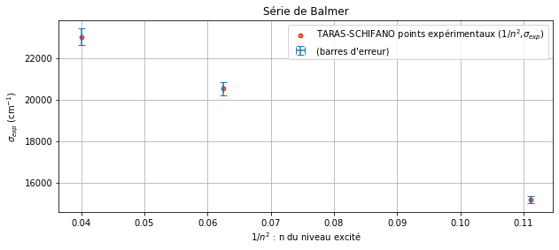

```python
#tracé
# les barres d'erreur ne concerne que le pointé de dH, où le nombre n est parfaitement déterminé
fig, bx = plt.subplots(figsize=(10,4))
bx.scatter(1/n**2,sigmaH,s=20,facecolor='C1', edgecolor='r',label=noms+" points expérimentaux ($1/n^2$,$\sigma_{exp}$)")
#bx.plot(1/n**2,sigmaH,label=noms+" segments de droite reliant les points expérimentaux ($1/n^2$,$\sigma_{exp}$)")
bx.errorbar(1/n**2,sigmaH,yerr=ΔσH, xerr=0, marker='',capsize=4,linestyle='',label="(barres d'erreur)")
bx.set_title("Série de Balmer")
bx.set_ylabel("$\sigma_{exp}$ (cm$^{-1}$)")
bx.set_xlabel("$1/n^2$ : n du niveau excité")
bx.legend()
bx.grid()
plt.show()
```

Les points expérimentaux sont-ils alignés ? Peut-on faire un ajustement linéaire ?

Réponse: oui

**Régression linéaire** : Lorsque des points expérimentaux s'alignent sans passer par l'origine on utilise un ajustement linéaire pour déterminer les paramètres de la droite $y=ax+b$ où $a$ est la pente et $b$ l'ordonnée à l'origine.  
Ces paramètres, déterminés grâce au module `scipy` par la fonction `sc.optimize.curve_fit(line,1/n**2,sigmaH,sigma=ΔσH)` qui prend en compte l'incertitude $\Delta y$, doivent pouvoir être interprétés physiquement.

Ici $y\rightarrow \sigma_H$ et $x\rightarrow \frac{1}{n^2}$ reliées par la fonction `def line(x,a,b): return -a*x+b` soit $\sigma_H=R_H \left ( \frac{1}{2^2}-\frac{1}{n^2} \right) =\overbrace{ -R_H}^{-(a\rightarrow \text{coef1})}\overbrace{\frac{1}{n^2}}^x + \overbrace{\frac{R_H}{2^2}}^{b\rightarrow \text{coef2}} $.

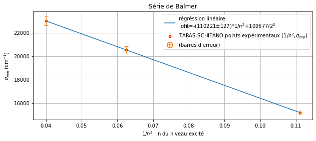

```
a (cm-1) = 110221.0 +/- 127.0
ordonnée à l'origine (cm-1) = 27419.0 +/- 12.0
```

```python
# régression linéaire  des données expérimentales de sigmaH= f(1/n**2) avec incertitude sur ΔσH
#coef1-> pente, coef2-> ordonnée à l'origine

def line(x,a,b):return -a*x+b
popt,pcov = sc.optimize.curve_fit(line,1/n**2,sigmaH,sigma=ΔσH)
coef1=popt[0];Δcoef1=pcov[0,0]**0.5;
coef2=popt[1];Δcoef2=pcov[1,1]**0.5;

#tracé
# les barres d'erreur ne concerne que le pointé de dH, où le nombre n est parfaitement déterminé
fig, bx = plt.subplots(figsize=(10,4))
bx.scatter(1/n**2,sigmaH,s=20,facecolor='C1', edgecolor='r',label=noms+" points expérimentaux ($1/n^2$,$\sigma_{exp}$)")
#bx.plot(1/n**2,sigmaH,label=noms+" segments de droite reliant les points expérimentaux ($1/n^2$,$\sigma_{exp}$)")
bx.plot(1/n**2, (line(1/n**2, coef1,coef2)), label=f"régréssion linéaire \n σfit=-({coef1:.0f}\u00B1{Δcoef1:.0f})*$1/n^2$+{coef2*4:.0f}/$2^2$ ")
bx.errorbar(1/n**2,sigmaH,yerr=ΔσH, xerr=0, marker='',capsize=4,linestyle='',label="(barres d'erreur)")
bx.set_title("Série de Balmer")
bx.set_ylabel("$\sigma_{exp}$ (cm$^{-1}$)")
bx.set_xlabel("$1/n^2$ : n du niveau excité")
bx.legend()
bx.grid()
plt.show()

print('a (cm-1) =',np.round(coef1,0),"+/-",np.round(Δcoef1,0))
print("ordonnée à l'origine (cm-1) =",np.round(coef2,0),"+/-",np.round(Δcoef2,0))
```

Commenter ce résultat: On obtient une relation linéaire entre le nombre et l'inverse du carré du niveau d'éxcitation de l'atome.

$\Rightarrow$ en déduire la constante de Rydberg et son incertitude accessibles dans cette expérience :

**Faire valider cette mesure par l'encadrant de TP**

```python
print(f"constante expérimentale (eV)={coef1*h*c*100/e:.2f}\u00B1{Δcoef1*h*c*100/e:.2f}")
print('constante connue(eV)=',RH_theo*(h*c*100)/e)
```

[output not shown]

```python
#pour informations.
Ry=13.605693009 #constante infinie de Rydberg pour un système hydrogénoïde pour lequel la masse du noyau est "infinie"
me=9.1e-31
mp=1838*me
RH=Ry/(1+me/mp)#constante de Rydberg pour l'hydrogène dans lequel le rapport entre masse de l'électron et masse du proton est 1838
RH
```

```
13.598294589745514
```

- Le fichier html créé, peut être converti en pdf par impression dans un fichier pdf depuis n'importe quel navigateur. Il est possible de copier/coller les tableaux et les graphes depuis le Notebook ou le fichier html vers un fichier Word ou LibreOffice. Ce qui vous permet de ne pas "retaper" toutes vos données collectées et analysées durant la séance de TP.
- Ce Notebook peut aussi être téléchargé à partir du menu déroulant de `Fichier`. Il vous suffit d'installer anaconda3 sur votre machine pour utiliser ce notebook et le transformer pour écrire votre compte-rendu.

```python
# indiquer le nom de votre notebook à la place de "TP4_OPS_Etudiants.ipynb"
!jupyter nbconvert  --to html  "TP4_TARAS_SCHIFANO.ipynb"
#!jupyter nbconvert  --to html --no-input "TP4_OPS_Etudiants.ipynb" #document sans les cellules de code python
```